INVESTIGATION · WOMEN'S SAFETY · RESTORE BRITAIN

# She Called for the Protection of All Girls. Then Orla Minihane Faced Abuse From Restore Britain Supporters.

The Pink Ladies founder's appeal to protect girls of every ethnicity triggered a backlash. Weeks later she had resigned from Rupert Lowe's party, alleging abuse involving her own family. By 22 September, the company associated with the Pink Ladies was dissolved.

Steve English · 11 October 2026

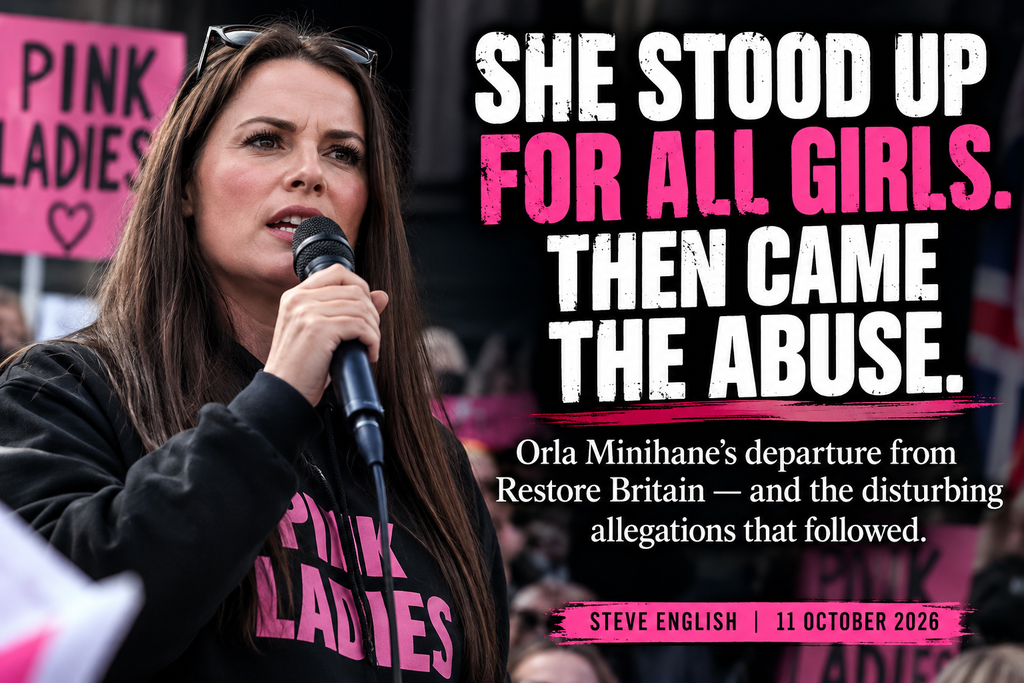

Editorial illustration; not a documentary photograph.

## Summer 2025: A women's movement emerges

Orla Minihane helped build the Pink Ladies into a women-led campaign associated with protests over asylum accommodation and concerns about women's safety. The movement gained attention during demonstrations in Epping and spread into other regions. It was a movement with a contested political message, but Minihane's later insistence that girls of all backgrounds deserved protection was unambiguous.

## 13 November 2025: The company is formed

Pink Ladies Services Limited (company number 16853741) was incorporated. Companies House lists Orla Anne Minihane and Vikki Louise Smith as directors appointed that day.

## 2026: A prominent Restore Britain role

Minihane became Restore Britain's spokeswoman for the safety of women and girls. Public reporting places her in that role by August 2026. The precise appointment date should be confirmed against the original announcement before it is printed as fact.

## Late August: The speech that ignited a backlash

At a Gateshead event, Minihane said girls born in Britain from Indian, Pakistani, Bangladeshi and Somali backgrounds were also suffering exploitation and needed protection. Searchlight documented hostile reactions from Restore-associated commentators, including Sam Wilkes, who criticised the video.

“We've got to protect our girls ... [and] we have got to protect them also.”

Whatever one's position on immigration, the underlying principle is clear: a child facing abuse should not be excluded from protection because of ethnicity.

## 1 September: Minihane resigns

On 1 September 2026, Minihane resigned as Restore Britain's spokeswoman. She said she would focus on her Pink Ladies work and campaigning for women's safety.

## 9 September: Allegations involving her family

In an account reported by Searchlight, Minihane said much of the abuse came from within Restore Britain. She described abuse affecting her daughter and an especially disturbing alleged incident involving a photograph of her young nieces and a message indicating that the sender knew their school.

The allegation is serious. The sender's identity and party membership have not been independently established in the reporting reviewed. Threatening or intimidating children has no legitimate place in political disagreement.

## Other former insiders raise concerns

On 4 September, former North East organiser Nick Seton-Rogers described what he called a “very nasty underbelly” and a “deeply misogynistic” culture within Restore, and criticised the response from party headquarters to Minihane's treatment. On 18 September, former Restore candidate Jez Hermer separately alleged racism, antisemitism and misogyny in party-associated circles. These remain attributed allegations, not judicial findings.

Searchlight's reporting and a separate Telegraph investigation also described derogatory comments concerning Minihane's Irish ancestry and alleged remarks about women's place in politics. Restore Britain has disputed broader allegations about its culture.

## 22 September: Pink Ladies Services Limited dissolved

The [official Companies House register](https://find-and-update.company-information.service.gov.uk/company/16853741) records that **Pink Ladies Services Limited was dissolved on 22 September 2026**, 21 days after Minihane resigned from Restore Britain. The company had been incorporated on 13 November 2025 and existed for just over ten months.

The register establishes the dissolution, not its cause. It does not demonstrate that Restore Britain caused the company's closure.

## Source documents

1. [Searchlight: reaction to the Gateshead speech (August 2026)](https://searchlightmagazine.com/2026/08/rupert-lowes-nazi-problem-erupts-into-open-revolt/)
2. [Searchlight: resignation (1 September 2026)](https://searchlightmagazine.com/2026/09/orla-minihane-resigns-restore-leadership-role-after-partys-nazi-faction-turns-on-her/)
3. [Searchlight: Nick Seton-Rogers (4 September 2026)](https://searchlightmagazine.com/2026/09/restore-britain-tells-north-east-organiser-accept-it-or-fuck-off-so-he-did/)
4. [Searchlight: Minihane's allegations (9 September 2026)](https://searchlightmagazine.com/2026/09/orla-minihane-leaves-restore-blaming-culture-of-misogyny-and-abuse/)
5. [The Telegraph syndicated investigation (11 September 2026)](https://www.aol.com/articles/exclusive-restore-rising-star-quit-115536000.html)
6. [Searchlight: Jez Hermer (18 September 2026)](https://searchlightmagazine.com/2026/09/restores-ex-marine-election-candidate-slams-partys-overt-antisemitism-racism-and-misogyny/)
7. [Companies House: company overview and dissolution date](https://find-and-update.company-information.service.gov.uk/company/16853741)
8. [Companies House: directors](https://find-and-update.company-information.service.gov.uk/company/16853741/officers)